# Bayesian Regression Analysis of Skewed Tensor Responses

Inkoo Lee

Last Updated - April 22, 2022

## Paper

- Lee, I., Sinha, D., Mai, Q., Zhang, X. & Bandyopadhyay, D. (2021+). *Bayesian Regression Analysis of Skewed Tensor Responses.* [[Github]](https://github.com/InkooLee/BSTN)

## Skewed tensor response model

For an order-$K$ tensor response $\mathcal{Y}_i \in \mathbb{R}^{d_1 \times \cdots \times d_K}$ with a vector of covariates $\textbf{x}_i \in \mathbb{R}^p$, we consider a tensor response regression model

$$\begin{equation}\label{eq1}
\mathcal{Y}_{i} = \mathcal{B}\bar{\times}_{(K+1)} \textbf{x}_{i} + \mathcal{E}_{i},~~for~~ i=1,\ldots,n,~
\end{equation}$$
where $\mathcal{B} \in \mathbb{R}^{d_1 \times \cdots \times d_K \times p}$ is an order-$(K+1)$ unknown tensor of regression coefficients, $\bar{\times}_{(K+1)}$ is the $(K+1)$-mode vector product, and the error $\mathcal{E}_{i} \in \mathbb{R}^{d_1 \times \cdots \times d_K}$ is an order-$K$ tensor. We model the skewness in the distribution of $\mathcal{Y}$ via
$$\begin{equation}\label{eq2}
\mathcal{E}_{i} = |\mathcal{Z}_{2i}|\times_{K} \pmb{\Lambda} + \mathcal{Z}_{1i},
\end{equation}$$
where $\pmb{\Lambda} = diag(\lambda_1,\ldots,\lambda_{d_K}) \in \mathbb{R}^{d_K \times d_K}$ with skewness parameters $\pmb{\lambda}=(\lambda_1,\ldots,\lambda_{d_K})$ and $|\mathbf{M}|$ denotes the matrix whose each element of is the absolute value of the corresponding element of matrix $\mathbf{M}$.

## Tensor Spike-and-Slab prior

$$\begin{equation}\label{eq:IdentifyingCoef}
\begin{aligned}
&\mathcal{B}_{i_1 i_2 i_3 j} = \eta_{i_3j} + \gamma_{i_1i_2i_3 j},~~ \eta_{i_3j} \sim N(0, \tau^2)~~ for~~ \tau > 0
\end{aligned}
\end{equation}$$
and introduce sparsity via spike-and-slab priors as
$$\begin{equation}\label{eq:SparsePrior}
\gamma_{i_1i_2i_3j} \overset{iid}{\sim} (1 - \omega_{i_1
i_2 i_3 j})\delta_0(\gamma_{i_1i_2i_3 j}) + \omega_{i_1i_2i_3 j}N(0, \nu^2)~~ for~~ \nu > 0,
\end{equation}$$
where, $\delta_0(\cdot)$ is the indicator function at 0 and $\omega_{i_1i_2i_3 j} \overset{iid}{\sim} Bernoulli(\psi)$ with hyperprior $\psi \sim Beta(a,b)$. For the GAAD study, we choose $a = b = 0.1$, representing a vague hyperprior for $\psi$.

Since sparsity inducing prior on $\gamma_{i_1i_2i_3j}$ tends to concentrate around zero, $\mathcal{B}$ in is mostly determined by $\eta_{i_3j}$ allowing parsimonious interpretation of covariate effects, while estimates of $\mathcal{B}$ using Tensor Normal prior (with large-scale covariances) are much more different from each other.

## GAAD data analysis using `BSTN` package

```r
## Load package
library(BSTN)
```

We fit the BSTN (Bayesian skewed tensor normal) model with tensor SAS (spike-and-slab) prior.

```r
# n.burn = burn-in period, n.save = number of posterior samples, thin = thinning size
BSTN_SAS <- BSTN_SAS(Y,X,vecy, n.burn = 100, n.save = 1000, thin = 5)
```

### D-Statistic

$D = d_1/|d_2|$ for each regression effects $\mathcal{B}_{i_1i_2i_3j}$, where $d_1$ is distance of the Bayesian estimate (posterior median) from null value (0 here) and $d_2$ is the distance of the Bayes estimate from the nearest endpoint of the 95% CI of the parameter. Here, $D > 1.5$ $(D < -1.5)$ implies strong posterior evidence of positive (negative) effect of covariate $x_j$ on the biomarker $i_3$ at site $i_2$ of tooth $i_1$. Similarly, the range $-0.8 < D < 0.8$ suggests moderate evidence for null hypothesis, and $0.8 \leq D \leq 1.5$ represents moderate positive effect, and $-1.5 \leq D \leq -0.8$ denotes moderate negative effect of $x_j$ on $\mathcal{Y}_{i_1i_2i_3}$.

The following plot (Figure 1 in the main text) shows D-statistic map of tensor regression coefficients with sparsity inducing prior.

[output not shown]

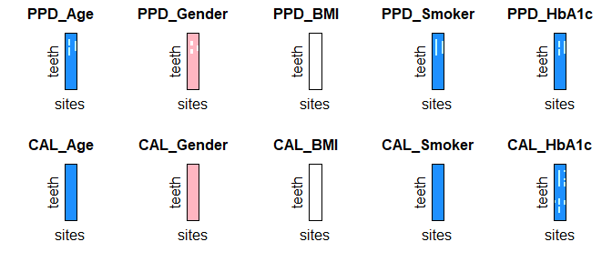

Now, the following plots (Figure A.3 in the Supplementary materials) represent residuals (real values - fitted values) for PPD & CAL of randomly picked patient.

```r
library(lattice);library(viridisLite)
```

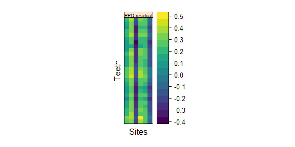

```r
t = 28; s = 6; b = 2; n = 290;

PPD_resd <- array(resd_PPD[,38], dim = c(t,s))
CAL_resd <- array(resd_CAL[,38], dim = c(t,s))


col <- viridis(100)

PPD <- array(t(PPD_resd), dim = c(6,28,1))
dimnames(PPD) <- list(c(1:6),c(1:28),c("PPD residual"))
levelplot(PPD,par.strip.text=list(cex=0.55), xlab="Sites",ylab="Teeth", scales = list(draw = FALSE), col.regions = col)
```

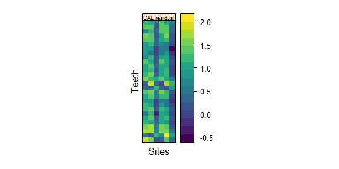

```r
CAL <- array(t(CAL_resd), dim = c(6,28,1))
dimnames(CAL) <- list(c(1:6),c(1:28),c("CAL residual"))
levelplot(CAL,par.strip.text=list(cex=0.55), xlab="Sites",ylab="Teeth", scales = list(draw = FALSE), col.regions = col)
```